# Introduction to R

Laura Melissa Guzman and Juan Zuloaga

## Before you start

Make sure you have [R](https://cran.r-project.org) and [RStudio](https://rstudio.com/products/rstudio/download/) installed. If you have a mac, you also need to install Xtools from the app store. If you have windows you also need to install [Rtools](https://cran.r-project.org/bin/windows/Rtools/).

## Getting around Rstudio

R studio is a friendlier way to use R. When you open RStudio you will see four panes.

You can open a new script by clicking *File* > *New File* > *R Script*

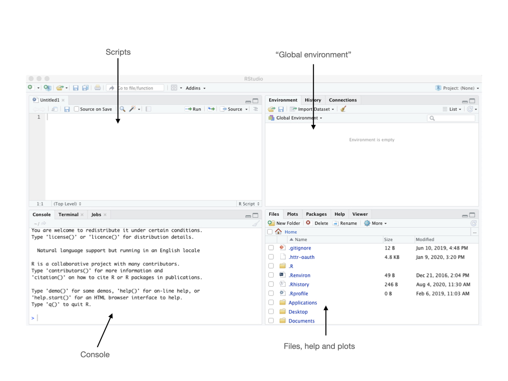

We will work by typing in the script.

## R as a calculator

Let’s play with some numbers. You can use R as a plain calculator doing all of the basic operations such as addition, multiplication, division and substraction.

For instance, write a expresion (say 3 + 2) and then hit the run button to execute the line.

```r
3 + 2
```

```
## [1] 5
```

You can also do multiple calculations by using the semicolon (;) to separate multiple commands

```r
20 / 4; 14 - 8
```

```
## [1] 5
```

```
## [1] 6
```

### Practice

Practice combining operators. Can you see the difference?

```r
14 - 8 * 2
```

```
## [1] -2
```

```r
(14 - 8) * 2
```

```
## [1] 12
```

**Tips!** The rules for the order of operations are important.

- Patenthesis () first, then
- Exponents (powers and square roots), then
- Multiplication and division (left-to-right), and finally
- Addition and substraction (left-to-right)

## Functions

R has many built in functions for common operations you might have seen before such as: “sqrt”, “log”, “abs”.

We will see lots of functions in R! And, R packages that are a collection of R functions.

**Square Root**

```r
sqrt(25)
```

```
## [1] 5
```

**Powers**

```r
3^2
```

```
## [1] 9
```

**Absolute value**

```r
abs(-43)
```

```
## [1] 43
```

**Natural logarithms (“log”**)

```r
log(10)
```

```
## [1] 2.302585
```

**Logarithms using base 10**

```r
log10(10)
```

```
## [1] 1
```

**Tips!** R is case sensitive, so ‘Log(10)’ will not work at all.

You will get an error:

Error in Log10() : could not find function “Log10”

**Trigonometric functions: e.g., sin (“sin”**)

```r
sin(pi/2)
```

```
## [1] 1
```

## Mathematical constants

R also knows commonly used mathematical constants such as π

```r
pi
```

```
## [1] 3.141593
```

More generally, Functions will execute certain actions. You can call functions by writing the name of the function followed by round parenthesis ().

**Tips!**

When you are typing the name of a function, R is actively searching for functions with similar spelling, so you can select the one you are looking for. See the example below:

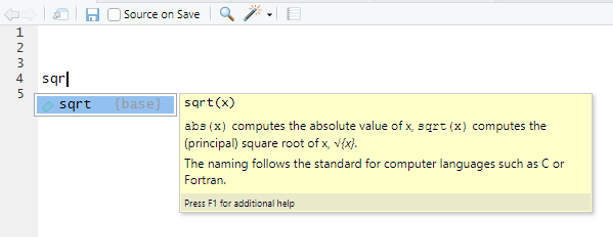

Functions can be very useful. For instance, let’s use **“round”** to round the mathematical constant ‘π’ to two decimal places.

```r
round(pi, 2)
```

```
## [1] 3.14
```

rounds down, using **“floor”** function

```r
floor(19.8)
```

```
## [1] 19
```

rounds up, using **“ceiling”** function

```r
ceiling(19.8)
```

```
## [1] 20
```

**This is your turn!**

**Tips!**

Practice, practice, practice!!

Hopefully you get lots of **Error** messages.

Try to understand what are the issues and solve them.

Your learning process will improve substantially

## What is an object in R

R is an objet-oriented program. It means that everything in R is an object.

So, an object in R is a structure having some attributes (data type) and methods acting in its attributes.

Let’s talk about the first part, the **data type**. For instance, the most basic data type in R is a **vector** which refers to an atomic quantity that can hold only one value.

```r
x <- 1
x
```

```
## [1] 1
```

You can use vectors to build more complex ones.

Let’s see types of vectors (modes: numeric, logic and character)

**Number**

```r
a <- 5
a
```

```
## [1] 5
```

You can use the function **“class”** to see the ‘mode’ of the object.

```r
class(a)
```

```
## [1] "numeric"
```

```r
b <- 7
b
```

```
## [1] 7
```

Checking for numeric type

```r
b <- 7
typeof(b)
```

```
## [1] "double"
```

All real numbers are stored in double precision format. If you requiered integer use the function **“as.integer”**:

```r
b <- 7
as.integer(b)
```

```
## [1] 7
```

```r
s <- 10.2
as.integer(s)
```

```
## [1] 10
```

**Logical value**

Is **a** larger than **b**? (Remember **a** is 5 and **b** is 7)

```r
m <- a > b
m
```

```
## [1] FALSE
```

Is **a** smaller than **b**?

```r
n <- a < b
n
```

```
## [1] TRUE
```

```r
class(n)
```

```
## [1] "logical"
```

**Character (string)**

```r
c <- "rain"
c
```

```
## [1] "rain"
```

```r
class(c)
```

```
## [1] "character"
```

Remember to use quotation marks to encapsule the string (e.g., “rain”). Otherwise you will get an error. Try it!

Let’s try this. Numbers within quotation marks.

```r
d <- "8"
```

```r
e <- "9"
```

Then, d + e (are you expecting 17?)

You will get an error:

Error in d + e : non-numeric argument to binary operator

You can coerce these character mode objects into a number, using the function **“as.numeric”**

```r
as.numeric(d) + as.numeric(e)
```

```
## [1] 17
```

At this point you might notice that we are using this operator:

**<-**

**Tips!**

**<-** is the preferred assigment operator in R.

**<-** always means assigment.

Whereas **=** can mean assigment, function argument binding or case statement (you will see more details on this later on).

Good practice: use **<-** to assign values to an object.

Data types

Same mode

Different mode

1 dimension

**Vector**

**list**

e.g., (2,3,4,5)

e.g., (3, “frog”, 3.5, FALSE)

2 dimension

**Matrix**

**data frame**

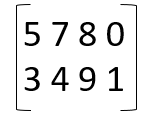

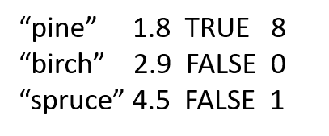

Before entering the world of more complex data types, let’s try to understand the second part of the the object’s definition:

An object in R is a structure having some attributes (data type) and **methods acting in its attributes**.

The next slide is an example that will give you a general idea.

We will come back with more examples later on.

```r
c <- "25"
```

```r
class(c)
```

```
## [1] "character"
```

Let’s try to perform this function sqrt(c)

You will get an error:

Error in sqrt(c) : non-numeric argument to mathematical function

This is because **“sqrt”** does not work on objects of mode ‘character’.

So, objects are not simply collection of data with different structures. Operations and functions are defined for speciefic classes and modes.

**Vectors**

A vector is a sequence of data elements of the same mode.

Let’s use the function concatenate **“c”** to create a vector

```r
c(2,4,6,8,10)
```

```
## [1]  2  4  6  8 10
```

Let’s use the function **“length”** to know the number of elements in this vector

```r
length(c(2,4,6,8,10))
```

```
## [1] 5
```

Let’s add this vector to an object

```r
even_numbers <- c(2,4,6,8,10)
even_numbers
```

```
## [1]  2  4  6  8 10
```